# Hadoop Learning

Tao Zou

2024-08-04

# Hadoop 组成

Hadoop 用来**存储**和**分析**海量数据，其组件为：

- HDFS: 负责数据存储。一个NameNode管理多个DataNode，Second NameNode负责辅助NameNode。
- Yarn: 负责资源调度。一个ResourceManager(RM)管理多个NodeManager。RM管理整个集群的内存和cpu。每个NodeManager上可以有多个container，用于运行任务。如果一个NodeManager上有2个cpu，则这个NM上最多可以同时运行2个container。
- MapReduce: 负责计算。Map阶段并行处理输入数据，Reduce阶段汇总结果。MapReduce好像用于离线计算，Spark可以用于内存计算。MapReduce的上层有Hive支持，Spark的上层有Spark MLlib、Spark SQL、Spark Streaming等支持。

[figure not shown]

# root用户相关

设置用户密码：

```bash
sudo passwd root
```

切换到root用户，输入下述命令，然后键入密码。

```bash
su root
```

# 虚拟机组成

## 硬件

我的联想电脑的CPU核心数为12。`虚拟机运行数量` * `每个虚拟机CPU数` * `每个CPU核心数` 不要超过12。

## IP

### 设置VMWare的IP地址

VMWare中，点击`编辑`->`虚拟网络编辑器`，会看见VMnet1和VMnet8。选中VMnet8，点击`更改设置`。再次点击`编辑`->`虚拟网络编辑器`，会看见VMnet0，VMnet1和VMnet8。选中VMnet8，可以将子网IP第三个八位字节设置为10（如192.168.10.0）。点击NAT设置，将网关IP也同样设置（网关IP的第四个八位字节一般是2）。最后，点击`虚拟网络编辑器`中的确定。

### 本机Windows中设置VMnet8的地址

在本机中，点击`以太网`->`更改适配器选项`->`VMWare Network Adapter VMnet8`->`属性`->`Internet协议版本 4`。按照下图配置。

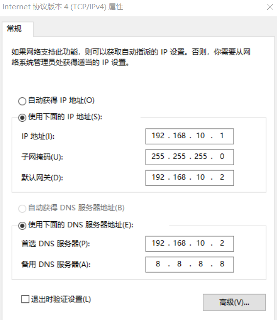

### 虚拟机内部设置IP地址

打开文件。如果识别不出vim命令，则需要下载`apt install vim`。

```bash
su root
sudo vim /etc/netplan/01-netcfg.yaml
```

键入`i`进入编辑模式。

```yaml
network:
  version: 2
  renderer: networkd
  ethernets:
    ens33:
      dhcp4: no
      addresses:
        - 192.168.10.100/24
      gateway4: 192.168.10.2
      nameservers:
        addresses:
          - 192.168.10.2
```

按`Esc`，再键入`:wq`可以保存修改的内容。

应用更改：

```bash
sudo netplan apply
```

修改主机名称：

```bash
vim /etc/hostname
```

建立IP地址与主机名的映射关系：

```bash
sudo vim /etc/hosts
```

增加下述内容：

```
192.168.10.100 hadoop100
192.168.10.101 hadoop101
192.168.10.102 hadoop102
192.168.10.103 hadoop103
192.168.10.104 hadoop104
192.168.10.105 hadoop105
192.168.10.106 hadoop106
192.168.10.107 hadoop107
192.168.10.108 hadoop108
```

1. 使用`ifconfig`检查ens33部分的内容，查看inet是否为`192.168.10.100`。
2. 然后再`ping www.baidu.com`看看是否能访问外网。
3. `hostname`查看主机名称是否为hadoop100

在克隆出的新的虚拟机中，需要修改`01-netcfg.yaml`中的ens33 的 addresses 为`192.168.10.102`、`192.168.10.103`等，以及修改主机名即可。

# 安装Hadoop、JDK

## 安装JDK

解压文件，在压缩包路径下运行下述命令，-C参数指定解压路劲。

```bash
tar -zxvf jdk-22_linux-x64_bin.tar.gz -C /home/zt/development/JDK17
```

配置Java环境变量，创建一个环境文件`my_env.sh`：

```bash
cd /etc/profile.d
sudo vim my_env.sh
```

编写Java环境变量

```bash
#JAVA_HOME
export JAVA_HOME=/home/zt/development/JDK17/jdk-22.0.1
export PATH=$PATH:$JAVA_HOME/bin
```

刷新

```bash
source /etc/profile
java -version
```

```bash
# 查看Ubantu机环境变量
echo $PATH
```

## 安装Hadoop

参照安装JDK，解压->打开`my_env.sh`，编写环境：

```bash
#HADOOP_HOME
export HADOOP_HOME=/home/zt/development/Hadoop336/hadoop-3.3.6
export PATH=$PATH:$HADOOP_HOME/bin
export PATH=$PATH:$HADOOP_HOME/sbin
```

```bash
source /etc/profile
```

# Hadoop介绍

## Hadoop重要文件结构

运行下述命令查看Hadoop命令。

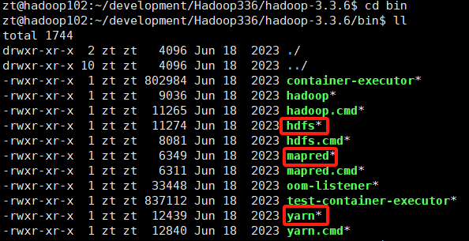

```bash
cd ~/Hadoop336/hadoop-3.3.6/bin
ls
```

运行下述命令查看配置文件。

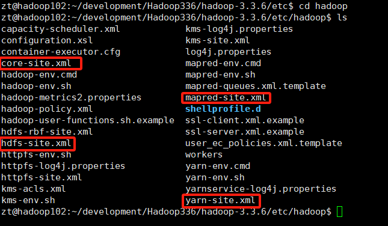

```bash
cd ~/Hadoop336/hadoop-3.3.6/etc/hadoop
ls
```

运行下述命令，查看集群配件相关启动命令。

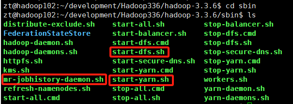

```bash
cd ~/Hadoop336/hadoop-3.3.6/sbin
ls
```

## Hadoop本地模式

新建一个.txt文档如下：

```
aa bb
cc aa
```

运行下述命令（我在hadoop-3.3.6目录下运行的）：

```bash
hadoop jar share/hadoop/mapreduce/hadoop-mapreduce-examples-3.3.6.jar wordcount myinput/word.txt myoutput
```

输出文件会被保存在新创建的文件夹myoutput中，myoutput文件夹须由hadoop创建，该文件夹不能预先存在。

## Hadoop分布式模式

### 复制文件到其他节点

```bash
# 从hadoop102拷贝jdk-22.0.1到hadoop103相同目录下
scp -r /home/zt/development/JDK17/jdk-22.0.1 zt@hadoop103:/home/zt/development/JDK17
```

```bash
# 从hadoop103拉取hadoop102的hadoop-3.3.6
scp -r zt@hadoop102:/home/zt/development/Hadoop336/hadoop-3.3.6 ./
```

```bash
# 在hadoop103执行命令将hadoop102的jdk-22.0.1和hadoop-3.3.6拷贝到hadoop104上
scp -r zt@hadoop102:/home/zt/development/* zt@hadoop104:/home/zt/development
```

运行上述命令时报错了，显示`连接zt@hadoop104 denied`。但是我从`zt@hadoop103`上传送本节点的文件到`zt@hadoop104`却是没有任何问题的。

### 同步文件到其他节点

```bash
rsync -av /home/zt/development/Hadoop336/hadoop-3.3.6 zt@hadoop104:/home/zt/development/hadoop-3.3.6
```

# 其他问题的解决方案

## VMWare虚拟机间歇性宕机

在VMWare主界面，`编辑->首选项->内存`，将预留内存调到最大。